# **Data Science Pipeline: Predicting Startup Success**

In the time of AI-pins and delivery food robots, it's exciting to see the new entreprenurial ventures that are being developed everyday. A 'startup' is a term for a early stage company that has just been founded. Where 'just' means within the last 10 ish years. Startups can often fail, as many don't manage to make profit or find lasting customers. But what are the distinguishing factors that causes some startups to be more successful than others? In this data-science pipeline, our group will go through our process and findings on what makes startups successful.

**Contributions Summary**

A: Project idea - 5%

- Annie 100%
- Cartor 100%

B: Dataset Curation and Preprocessing - 10%

- Annie 100%
- Cartor 100%

C: Data Exploration and Summary Statistics - 10%

- Annie 100%
- Cartor 100%

D: ML Algorithm Design/Development - 25%

- Annie 100%
- Cartor 100%

E: ML Algorithm Training and Test Data Analysis - 20%

- Annie 100%
- Cartor 100%

F: Visualization, Result Analysis, Conclusion - 15%

- Annie 100%
- Cartor 100%

G: Final Tutorial Report Creation - 10%

- Annie 100%
- Cartor 100%

H: Additional (not listed above, if any) - 5%

- Annie 100%
- Cartor 100%

We, all team members, agree together that the above information is true, and we are confident about our contributions to this submitted project/final tutorial

Cartor Hancock, 5/6/2024

Annie Zhou, 5/6/2024

**Member Contributions**

*Cartor Hancock:* Cartor contributed by working with Annie for project idea and development for section B,C, and F. He also worked primarily on development for D and F.

*Annie Zhou:* Annie contributed by working with Cartor for project idea and development for section B,C,and F. She also worked on creating the report (section H), hosting the project (section H), and ML algorithim design and analysis for section D and F.

# **Data Preprocessing**

The [dataset](https://www.kaggle.com/datasets/manishkc06/startup-success-prediction/data) that our group chose from Kaggle contains records about a wide variety of startups and the corresponding company information.

If you need to run the code below, please download the dataset at the link above and import it into the Colab Runtime.

```python
import pandas as pd
import numpy as np
import re
import seaborn as sns
import matplotlib.pyplot as plt
from sklearn.preprocessing import MinMaxScaler
from sklearn.cluster import KMeans
from scipy import stats
from scipy.stats import ttest_ind
from sklearn.decomposition import PCA
from sklearn.model_selection import train_test_split
from sklearn.tree import DecisionTreeClassifier
from sklearn.tree import export_text
from sklearn.metrics import accuracy_score
from scipy.stats import entropy
```

```python
df = pd.read_csv("startup data.csv")
print(df.columns)
```

```
Index(['Unnamed: 0', 'state_code', 'latitude', 'longitude', 'zip_code', 'id',
       'city', 'Unnamed: 6', 'name', 'labels', 'founded_at', 'closed_at',
       'first_funding_at', 'last_funding_at', 'age_first_funding_year',
       'age_last_funding_year', 'age_first_milestone_year',
       'age_last_milestone_year', 'relationships', 'funding_rounds',
       'funding_total_usd', 'milestones', 'state_code.1', 'is_CA', 'is_NY',
       'is_MA', 'is_TX', 'is_otherstate', 'category_code', 'is_software',
       'is_web', 'is_mobile', 'is_enterprise', 'is_advertising',
       'is_gamesvideo', 'is_ecommerce', 'is_biotech', 'is_consulting',
       'is_othercategory', 'object_id', 'has_VC', 'has_angel', 'has_roundA',
       'has_roundB', 'has_roundC', 'has_roundD', 'avg_participants',
       'is_top500', 'status'],
      dtype='object')
```

### All Columns

```python
print(df.head)
```

```
<bound method NDFrame.head of      Unnamed: 0 state_code   latitude   longitude zip_code       id  \
0          1005         CA  42.358880  -71.056820    92101   c:6669
1           204         CA  37.238916 -121.973718    95032  c:16283
2          1001         CA  32.901049 -117.192656    92121  c:65620
3           738         CA  37.320309 -122.050040    95014  c:42668
4          1002         CA  37.779281 -122.419236    94105  c:65806
..          ...        ...        ...         ...      ...      ...
918         352         CA  37.740594 -122.376471    94107  c:21343
919         721         MA  42.504817  -71.195611     1803  c:41747
920         557         CA  37.408261 -122.015920    94089  c:31549
921         589         CA  37.556732 -122.288378    94404  c:33198
922         462         CA  37.386778 -121.966277    95054  c:26702

              city              Unnamed: 6                  name  labels  ...  \
0        San Diego                     NaN           Bandsintown       1  ...
```

[output cut: 38 more lines]

To explain some terminology about startups:

- **Venture Capital** (VC) firms are typically companies that invest in startups early on in the hopes that the startup will be successful and be worth a lot of money in roughly 10 years. They spread investments across many companies to diversify their stake and minimize risk.
- **Angel investors** are typicaly one individual or a family that have a large amount of money. They also are looking to invest, but they don't have enough money to invest in many startups. Thus, Angel investors typically wait until they find a company in a space they know pretty well, and then invest in the team and idea.

Now let's explain some column names in this dataset:

- labels = success of startup (1 is good)
- had_vc = venture capital, i.e. investment
- is_round[A-D] = at what stage (A-D) did the startup get VC investment
- angel = angel investor (really rich singular person that invests in a startup. Not a VC company)

## **Data Organization Tasks**

### Remove `Unamed: 0`, `Unamed: 6`, & `State_Code.1`

```python
df = df.drop(columns=['Unnamed: 0', 'Unnamed: 6', 'state_code.1'])
```

### Remove (`c:____`) prefix from `Object_Id` and `Id`. Also, remove Object_Id duplicates

```python
# Remove "c:" from id & object_id
df["id"] = df["id"].str[2:]
df["object_id"] = df["object_id"].str[2:]
```

```python
# Check if id matches oject_id
print(np.mean(df["id"] == df["object_id"]))
```

```
1.0
```

```python
# Since id = object_id, delete object_id
df = df.drop(columns=['object_id'])
```

### Remove status column since it's the same as labels column

```python
# Check if id matches oject_id
print(np.mean(df["labels"] == [{"acquired":1, "closed":0}[item] for item in df["status"]]))
```

```
1.0
```

```python
# Since labels = status, delete status
df = df.drop(columns=['status'])
```

```python
print(df.head)
```

```
<bound method NDFrame.head of     state_code   latitude   longitude zip_code     id           city  \
0           CA  42.358880  -71.056820    92101   6669      San Diego
1           CA  37.238916 -121.973718    95032  16283      Los Gatos
2           CA  32.901049 -117.192656    92121  65620      San Diego
3           CA  37.320309 -122.050040    95014  42668      Cupertino
4           CA  37.779281 -122.419236    94105  65806  San Francisco
..         ...        ...         ...      ...    ...            ...
918         CA  37.740594 -122.376471    94107  21343  San Francisco
919         MA  42.504817  -71.195611     1803  41747     Burlington
920         CA  37.408261 -122.015920    94089  31549      Sunnyvale
921         CA  37.556732 -122.288378    94404  33198  San Francisco
922         CA  37.386778 -121.966277    95054  26702    Santa Clara

                     name  labels founded_at  closed_at  ... is_consulting  \
0             Bandsintown       1   1/1/2007        NaN  ...             0
```

[output cut: 38 more lines]

### Removing confusing values from Closed column

```python
print(df['closed_at'].isnull())
```

```
0       True
1       True
2       True
3       True
4      False
       ...
918     True
919    False
920    False
921     True
922     True
Name: closed_at, Length: 923, dtype: bool
```

```python
condition = (((df['labels'] == 0) & (~df['closed_at'].isnull())) | ((df['labels'] == 1) & (df['closed_at'].isnull())))
def check_closed_at():
  condition = (((df['labels'] == 0) & (~df['closed_at'].isnull())) | ((df['labels'] == 1) & (df['closed_at'].isnull())))
  print( df[~condition] ) # == len(df))
check_closed_at()
```

```
    state_code   latitude   longitude        zip_code     id           city  \
73          CA  37.779026 -122.401840           94103    170  San Francisco
104         CA  37.748676 -122.415813           94110   4622  San Francisco
291         MD  39.232878  -76.820467  Maryland 21045  20062       Columbia
342         TX  30.409765  -97.751010           78759  44434         Austin
381         CA  37.502742 -122.211281           94063    975   Redwood City
445         MA  37.090240  -95.712891            2142   1725      Cambridge
473         CA  39.762314 -104.982256           94010    465     Burlingame
560         CA  37.776618 -122.393893           94107   1541  San Francisco
756         CA  37.398022 -122.049143           94043   3610  Mountain View

                  name  labels founded_at   closed_at  ... is_consulting  \
73             adBrite       1   1/1/2003    2/1/2001  ...             0
104           Aardvark       1   7/1/2007    9/1/2011  ...             0
291         Heartscape       1   1/1/2000  10/15/2009  ...             0
```

[output cut: 30 more lines]

The following row are Aquired, but still have a closing date: `73, 104, 291, 342, 381, 445, 473, 560, 756`

Thus we will remove their dates bc they do not match with the way the rest of the data is formatted and may interefer with analysis of closed_at of failed startups

```python
df.loc[~condition, "closed_at"] = pd.NaT
```

```python
check_closed_at()
```

```
Empty DataFrame
Columns: [state_code, latitude, longitude, zip_code, id, city, name, labels, founded_at, closed_at, first_funding_at, last_funding_at, age_first_funding_year, age_last_funding_year, age_first_milestone_year, age_last_milestone_year, relationships, funding_rounds, funding_total_usd, milestones, is_CA…
Index: []

[0 rows x 44 columns]
```

### Checking if all of the Has_Roud_A through Has_Round_D values are continous.

```python
pattern = '0*1*0*'
columns_to_check = ['has_roundA', 'has_roundB', 'has_roundC', 'has_roundD']

def matches_pattern(row):
    row_str = ''.join(str(row[col]) for col in columns_to_check)
    return re.fullmatch(pattern, row_str) is not None

continuous_rows = df.apply(matches_pattern, axis=1)
print(len(df) - len(df[continuous_rows]))
print(df[~continuous_rows])
```

```
16
    state_code   latitude   longitude zip_code     id                 city  \
7           CA  38.057107 -122.513742    94901   5192           San Rafael
8           MA  42.712207  -73.203599     1267   1043         Williamstown
28          TX  30.265344  -97.743586    78701  36920               Austin
163         CA  37.560155 -122.285588    94404  15693            San Mateo
274         CA  37.789429 -122.276524    94501  16892              Alameda
322         GA  33.786263  -84.387794    30309  23756           NW Atlanta
340         CA  37.388077 -122.083160    94041     86        Mountain View
377         CA  37.626166 -122.411025    94066   6012            San Bruno
404         CA  37.381876 -121.959930    95054  13681          Santa Clara
419         MA  42.528635  -71.278022     1821  27163            Billerica
469         MA  42.492256  -71.134549     1864  12052        North Reading
495         PA  39.952399  -75.163590    19104  24727         Philadelphia
572         CA  37.352313 -121.967982    95054  26556          Santa Clara
```

[output cut: 59 more lines]

## **Data Cleaning Tasks**

### Check For Duplicates

```python
for column in df.columns:
    duplicated_rows = df[df.duplicated(subset=[column], keep=False)]
    non_duplicate_count = len(df) - len(duplicated_rows)
    percent_non_duplicate = non_duplicate_count / len(df) * 100
    if len(duplicated_rows) > 0 and non_duplicate_count > .6 * len(df):
        print(f"Total non-duplicate rows in {column}: \t\t {non_duplicate_count}/{len(df)} | {percent_non_duplicate:.2f}%")
        if non_duplicate_count > .99 * len(df):
          print("\t\tIndices of duplicated rows:", duplicated_rows.index.tolist())
```

```
Total non-duplicate rows in latitude: 		 579/923 | 62.73%
Total non-duplicate rows in longitude: 		 577/923 | 62.51%
Total non-duplicate rows in id: 		 921/923 | 99.78%
		Indices of duplicated rows: [124, 832]
Total non-duplicate rows in name: 		 921/923 | 99.78%
		Indices of duplicated rows: [124, 832]
Total non-duplicate rows in age_last_funding_year: 		 628/923 | 68.04%
```

```python
print(df.iloc[832])
print("------")
print(df.iloc[124])
```

```
state_code                               CA
latitude                           37.48151
longitude                       -121.945328
zip_code                              94538
id                                    28482
city                                Fremont
name                        Redwood Systems
labels                                    1
founded_at                         1/1/2008
closed_at                               NaN
first_funding_at                  10/3/2008
last_funding_at                   5/30/2012
age_first_funding_year               0.7562
age_last_funding_year                4.4137
age_first_milestone_year             2.7836
age_last_milestone_year              4.0027
relationships                            14
funding_rounds                            4
funding_total_usd                  34250000
milestones                                2
is_CA                                     1
is_NY                                     0
is_MA                                     0
is_TX                                     0
is_otherstate                             0
category_code                     cleantech
is_software                               0
is_web                                    0
is_mobile                                 0
is_enterprise                             0
is_advertising                            0
is_gamesvideo                             0
is_ecommerce                              0
is_biotech                                0
is_consulting                             0
is_othercategory                          1
has_VC                                    1
has_angel                                 0
has_roundA                                1
has_roundB                                1
```

[output cut: 36 more lines]

```
is_advertising                            0
is_gamesvideo                             0
is_ecommerce                              0
is_biotech                                0
is_consulting                             0
is_othercategory                          1
has_VC                                    1
has_angel                                 0
has_roundA                                1
has_roundB                                1
has_roundC                                1
has_roundD                                0
avg_participants                       2.25
is_top500                                 1
Name: 124, dtype: object
```

```python
print(df.iloc[832] == df.iloc[124])
```

```
state_code                   True
latitude                    False
longitude                   False
zip_code                     True
id                           True
city                         True
name                         True
labels                       True
founded_at                   True
closed_at                   False
first_funding_at             True
last_funding_at              True
age_first_funding_year       True
age_last_funding_year        True
age_first_milestone_year     True
age_last_milestone_year      True
relationships                True
funding_rounds               True
funding_total_usd            True
milestones                   True
is_CA                        True
is_NY                        True
is_MA                        True
is_TX                        True
is_otherstate                True
category_code                True
is_software                  True
is_web                       True
is_mobile                    True
is_enterprise                True
is_advertising               True
is_gamesvideo                True
is_ecommerce                 True
is_biotech                   True
is_consulting                True
is_othercategory             True
has_VC                       True
has_angel                    True
has_roundA                   True
has_roundB                   True
has_roundC                   True
has_roundD                   True
avg_participants             True
is_top500                    True
dtype: bool
```

```python
print(df.iloc[832][["latitude", "longitude", "closed_at"]])
print("------")
print(df.iloc[124][["latitude", "longitude", "closed_at"]])
```

```
latitude       37.48151
longitude   -121.945328
closed_at           NaN
Name: 832, dtype: object
------
latitude       37.54827
longitude   -121.988572
closed_at           NaN
Name: 124, dtype: object
```

### Check For Nans

```python
for column in df.columns:
    nan_rows = df[df[column].isna()].index
    if not nan_rows.empty:
      print(f"NaN values found in {column} column at rows with indices: {nan_rows.tolist()}")
```

```
NaN values found in closed_at column at rows with indices: [0, 1, 2, 3, 6, 7, 8, 9, 10, 13, 14, 17, 18, 20, 25, 26, 27, 28, 29, 31, 33, 38, 39, 40, 41, 43, 44, 45, 46, 47, 48, 49, 50, 51, 52, 53, 54, 56, 57, 58, 59, 62, 64, 65, 67, 68, 69, 70, 71, 72, 73, 77, 78, 80, 83, 84, 86, 89, 90, 92, 93, 94, …
NaN values found in age_first_milestone_year column at rows with indices: [12, 15, 24, 32, 34, 37, 45, 55, 63, 66, 74, 76, 81, 85, 88, 91, 95, 99, 100, 101, 102, 111, 112, 116, 125, 135, 136, 140, 150, 163, 173, 180, 183, 184, 185, 197, 198, 201, 207, 209, 210, 213, 214, 215, 226, 230, 241, 250, 252…
NaN values found in age_last_milestone_year column at rows with indices: [12, 15, 24, 32, 34, 37, 45, 55, 63, 66, 74, 76, 81, 85, 88, 91, 95, 99, 100, 101, 102, 111, 112, 116, 125, 135, 136, 140, 150, 163, 173, 180, 183, 184, 185, 197, 198, 201, 207, 209, 210, 213, 214, 215, 226, 230, 241, 250, 252,…
```

```python
print(df.iloc[515])
```

```
state_code                          CA
latitude                     37.451124
longitude                  -122.166264
zip_code                         94025
id                                 856
city                        Menlo Park
name                              Cuil
labels                               0
founded_at                    1/1/2005
closed_at                     9/1/2010
first_funding_at              3/1/2007
last_funding_at              4/15/2008
age_first_funding_year          2.1616
age_last_funding_year           3.2877
age_first_milestone_year        3.4986
age_last_milestone_year         7.6904
relationships                       13
funding_rounds                       2
funding_total_usd             33000000
milestones                           4
is_CA                                0
is_NY                                0
is_MA                                0
is_TX                                0
is_otherstate                        0
category_code                   search
is_software                          0
is_web                               0
is_mobile                            0
is_enterprise                        0
is_advertising                       0
is_gamesvideo                        0
is_ecommerce                         0
is_biotech                           0
is_consulting                        0
is_othercategory                     1
has_VC                               0
has_angel                            0
has_roundA                           1
has_roundB                           1
has_roundC                           0
has_roundD                           0
avg_participants                   2.5
is_top500                            1
Name: 515, dtype: object
```

### Strings To Ints

```python
column_names = ['latitude', 'longitude', 'zip_code', 'id',
                'labels', 'relationships', 'funding_rounds', 'funding_total_usd', 'milestones',
                'is_CA', 'is_NY', 'is_MA', 'is_TX', 'is_otherstate',
                'is_software', 'is_web', 'is_mobile', 'is_enterprise', 'is_advertising', 'is_gamesvideo',
                'is_ecommerce', 'is_biotech', 'is_consulting', 'is_othercategory',
                'has_VC', 'has_angel', 'has_roundA']

for column in column_names:
    df[column] = pd.to_numeric(df[column], errors='coerce').fillna(0).astype(int)
```

```python
columns_to_convert = ['age_first_funding_year', 'age_last_funding_year', 'age_first_milestone_year', 'age_last_milestone_year']

for column in columns_to_convert:
    df[column] = pd.to_numeric(df[column], errors='coerce').astype(float)
```

### Strings To Datetimes

```python
#Dates should be changed into Date Time object
df["founded_at"] = pd.to_datetime(df["founded_at"])
df["first_funding_at"] = pd.to_datetime(df["first_funding_at"])
df["last_funding_at"] = pd.to_datetime(df["last_funding_at"])
df["closed_at"] = pd.to_datetime(df["closed_at"])
```

## **Final Dataset**

Now that we've finished our data preprocessing, we're ready to start the data exploration with our new data!

```python
df
```

|  | state_code | latitude | longitude | zip_code | id | city | name | labels | founded_at | closed_at | ... | is_consulting | is_othercategory | has_VC | has_angel | has_roundA | has_roundB | has_roundC | has_roundD | avg_participants | is_top500 |
| --- | --- | --- | --- | --- | --- | --- | --- | --- | --- | --- | --- | --- | --- | --- | --- | --- | --- | --- | --- | --- | --- |
| 0 | CA | 42 | -71 | 92101 | 6669 | San Diego | Bandsintown | 1 | 2007-01-01 | NaT | ... | 0 | 1 | 0 | 1 | 0 | 0 | 0 | 0 | 1.0000 | 0 |
| 1 | CA | 37 | -121 | 95032 | 16283 | Los Gatos | TriCipher | 1 | 2000-01-01 | NaT | ... | 0 | 0 | 1 | 0 | 0 | 1 | 1 | 1 | 4.7500 | 1 |
| 2 | CA | 32 | -117 | 92121 | 65620 | San Diego | Plixi | 1 | 2009-03-18 | NaT | ... | 0 | 0 | 0 | 0 | 1 | 0 | 0 | 0 | 4.0000 | 1 |
| 3 | CA | 37 | -122 | 95014 | 42668 | Cupertino | Solidcore Systems | 1 | 2002-01-01 | NaT | ... | 0 | 0 | 0 | 0 | 0 | 1 | 1 | 1 | 3.3333 | 1 |
| 4 | CA | 37 | -122 | 94105 | 65806 | San Francisco | Inhale Digital | 0 | 2010-08-01 | 2012-10-01 | ... | 0 | 0 | 1 | 1 | 0 | 0 | 0 | 0 | 1.0000 | 1 |
| ... | ... | ... | ... | ... | ... | ... | ... | ... | ... | ... | ... | ... | ... | ... | ... | ... | ... | ... | ... | ... | ... |
| 918 | CA | 37 | -122 | 94107 | 21343 | San Francisco | CoTweet | 1 | 2009-01-01 | NaT | ... | 0 | 0 | 0 | 0 | 1 | 0 | 0 | 0 | 6.0000 | 1 |
| 919 | MA | 42 | -71 | 1803 | 41747 | Burlington | Reef Point Systems | 0 | 1998-01-01 | 2008-06-25 | ... | 0 | 1 | 1 | 0 | 0 | 1 | 0 | 0 | 2.6667 | 1 |
| 920 | CA | 37 | -122 | 94089 | 31549 | Sunnyvale | Paracor Medical | 0 | 1999-01-01 | 2012-06-17 | ... | 0 | 0 | 0 | 0 | 0 | 0 | 0 | 1 | 8.0000 | 1 |
| 921 | CA | 37 | -122 | 94404 | 33198 | San Francisco | Causata | 1 | 2009-01-01 | NaT | ... | 0 | 0 | 0 | 0 | 1 | 1 | 0 | 0 | 1.0000 | 1 |
| 922 | CA | 37 | -121 | 95054 | 26702 | Santa Clara | Asempra Technologies | 1 | 2003-01-01 | NaT | ... | 0 | 1 | 0 | 0 | 0 | 1 | 0 | 0 | 3.0000 | 1 |

923 rows × 44 columns

# **Data Exploration**

## **Conclusion 1:**

**Intro:**

Since we want to find out what makes a successful startup, let's first explore if certain industries are more likely than others to have sucessful startups.

**Background:**

But what is success for a startup? Success will be defined here by whether or not the startup is **aquired** , which means it was purchased by another company. A company will buy all or a significant portion of a startup with the goal of integrating the startup within its own operations. We associate an aquisition with success since there are opportunities for growth, financial compensation, and recognition of the value of the startup's products, internal talent, and services.

**Exploratory Analysis**

Let's first use ANOVA Hypothesis Testing with alpha = 0.05 to assess the following claims about the startup data.

**H0:** There is no difference for the mean total count on whether the startup is aquired or not depending on the category of startup

**Ha:** There is a difference for the mean total count on whether the startup is aquired or not depending on the category of startup

In the dataset, the industries of each startup record is stored as a categorical variable in the column "category_code". Furthermore, whether or not the startup was aquired or not is stored as a binary value in the "labels" column. In order to perform ANOVA testing, let's make a crosstab that shows the counts for whether the startup is aquired depending on the industry.

```python
# Make a crosstab that calculates the counts between startup industry and if the startup is aquired
crosstab = pd.crosstab(df["labels"],df["category_code"])
crosstab
```

| category_code labels | advertising | analytics | automotive | biotech | cleantech | consulting | ecommerce | education | enterprise | fashion | ... | real_estate | search | security | semiconductor | social | software | sports | transportation | travel | web |
| --- | --- | --- | --- | --- | --- | --- | --- | --- | --- | --- | --- | --- | --- | --- | --- | --- | --- | --- | --- | --- | --- |
| 0 | 17 | 3 | 1 | 12 | 13 | 1 | 14 | 1 | 17 | 3 | ... | 2 | 5 | 4 | 11 | 6 | 52 | 0 | 0 | 1 | 51 |
| 1 | 45 | 16 | 1 | 22 | 10 | 2 | 11 | 3 | 56 | 5 | ... | 1 | 7 | 15 | 24 | 8 | 101 | 1 | 2 | 7 | 93 |

2 rows × 35 columns

Now we're ready to calculate the p-value and draw some conclusions for our hypothesis testing!

```python
# Calculate the p-value of the ANOVA Test
from scipy.stats import f_oneway
#1. Get the samples
advertising = np.array(crosstab["advertising"])
analytics = np.array(crosstab["analytics"])
automotive = np.array(crosstab["automotive"])
biotech = np.array(crosstab["biotech"])
cleantech = np.array(crosstab["cleantech"])
consulting = np.array(crosstab["consulting"])
ecommerce = np.array(crosstab["ecommerce"])
education = np.array(crosstab["education"])
enterprise = np.array(crosstab["enterprise"])
fashion = np.array(crosstab["fashion"])
finance = np.array(crosstab["finance"])
games_video = np.array(crosstab["games_video"])
hardware = np.array(crosstab["hardware"])
health = np.array(crosstab["health"])
hospitality = np.array(crosstab["hospitality"])
manufacturing = np.array(crosstab["manufacturing"])
medical = np.array(crosstab["medical"])
messaging = np.array(crosstab["messaging"])
mobile = np.array(crosstab["mobile"])
music = np.array(crosstab["music"])
network_hosting = np.array(crosstab["network_hosting"])
news = np.array(crosstab["news"])
other = np.array(crosstab["other"])
photo_video = np.array(crosstab["photo_video"])
public_relations = np.array(crosstab["public_relations"])
real_estate = np.array(crosstab["real_estate"])
search = np.array(crosstab["search"])
security = np.array(crosstab["security"])
semiconductor = np.array(crosstab["semiconductor"])
social = np.array(crosstab["social"])
software = np.array(crosstab["software"])
sports = np.array(crosstab["sports"])
transportation = np.array(crosstab["transportation"])
travel = np.array(crosstab["travel"])
web = np.array(crosstab["web"])

#2. Calculate the p-values
anova_res = f_oneway(advertising,analytics,automotive,biotech,cleantech,consulting,ecommerce,education,enterprise,fashion,finance,games_video,hardware,health,hospitality,manufacturing,medical,messaging,mobile,music,network_hosting,news,other,photo_video,public_relations,real_estate,search,security,semiconductor,social,software,sports,transportation,travel,web)
anova_pval = anova_res.pvalue
print("p-value is "+str(anova_pval))
```

```
p-value is 6.995785629234579e-07
```

Since our p-value 6.995785629234579e-07 is less than 0.05, we reject the null hypothesis.

If there is a difference in the mean total counts of a company being aquired or not stolen depending on the industry then we want to find out which industry category has a different mean. This can be done with a Post Hoc Analysis, which is outside the scope of CMSC320. However, we wanted to note this action as it would be good practice to do when the null hypothesis of an ANOVA Hypothesis Test is rejected.

Let's visualize the relationship between the startup industry and whether or not it was aquired to gain some more insight into the two variables.

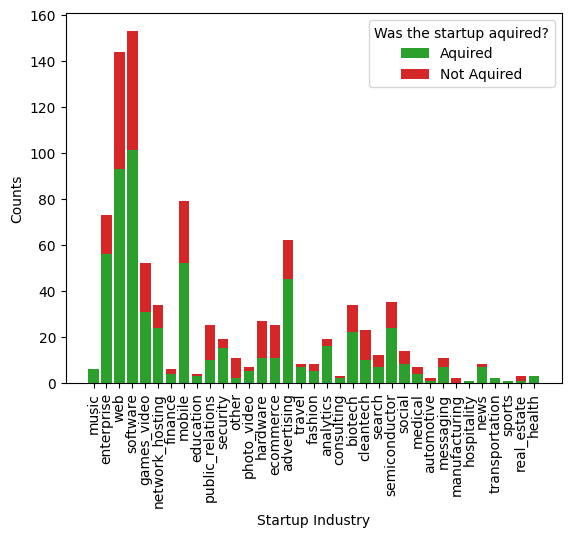

```python
#Visualize the crosstab
fig, ax = plt.subplots()

categories = df['category_code'].unique()
aquired = []
not_aquired = []
for i in range(len(categories)):
  category = categories[i]
  aquired.append(crosstab[category][1])
  not_aquired.append(crosstab[category][0])


bar1 = plt.bar(categories,aquired,color='tab:green',label="Aquired");
bar2 = plt.bar(categories,not_aquired,bottom=aquired, color='tab:red',label="Not Aquired");

ax.set_ylabel('Counts')
ax.set_xlabel('Startup Industry')

ax.legend(title='Was the startup aquired?',loc="upper right")
plt.xticks(rotation=90)

plt.show()
```

**Conclusion:**

To summarize, we explored the relationship between startup industry and success using the metric of it being an aquired company. Using ANOVA hypothesis testing, we rejected the hypothesis that the mean number of aquired companies is the same among all startup industries. In addition, we can conclude from our bar graph that industries like enterprise, web, software, and mobile have the most counts of aquired and not aquired startups. Although, its unclear if certain startup industries were over or under represented in the dataset without investigating the process of data-collection from the original dataset

## **Conclusion 2:**

**Intro:**

Are there States that are better suited for certain startup industries? How does State and Industry Affect Success of Startups?

**Background:**

People consider California a Tech startup haven. Is this true? Are the odds of success in tech startups higher in California?

In order to view this we need a vizualization method that can handle 3 variables, but more specifically 2 categorical variables and their effect on a numerical variable. The best method we thought of for this is a Heat Map as it can have 2 cateogorical variables spread on the X & Y with a summary statistic of the numerical variable in the cells (we chose average rate of success).

**Exploratory Analysis**

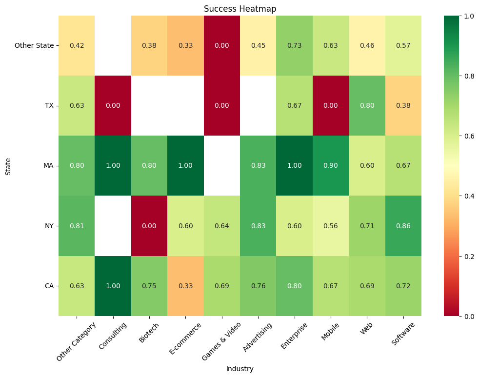

```python
heatmap_data = df.groupby(['is_CA', 'is_NY', 'is_MA', 'is_TX', 'is_otherstate',
                           'is_software', 'is_web', 'is_mobile', 'is_enterprise',
                           'is_advertising', 'is_gamesvideo', 'is_ecommerce',
                           'is_biotech', 'is_consulting', 'is_othercategory'])['labels'].mean().reset_index()

heatmap_data = heatmap_data.pivot_table(index=['is_CA', 'is_NY', 'is_MA', 'is_TX', 'is_otherstate'],
                                        columns=['is_software', 'is_web', 'is_mobile', 'is_enterprise',
                                                 'is_advertising', 'is_gamesvideo', 'is_ecommerce',
                                                 'is_biotech', 'is_consulting', 'is_othercategory'],
                                        values='labels', aggfunc='mean')

state_labels = ['CA', 'NY', 'MA', 'TX', 'Other State'][::-1]
industry_labels = ['Software', 'Web', 'Mobile', 'Enterprise', 'Advertising',
                   'Games & Video', 'E-commerce', 'Biotech', 'Consulting', 'Other Category'][::-1]

plt.figure(figsize=(12, 8))
sns.heatmap(heatmap_data[1:], cmap='RdYlGn', annot=True, fmt=".2f", cbar=True)
plt.title('Success Heatmap')
plt.xlabel('Industry')
plt.xticks(ticks=np.arange(len(industry_labels)) + 0.5, labels=industry_labels, rotation=45)
plt.ylabel('State')
plt.yticks(ticks=np.arange(len(state_labels))  + 0.5, labels=state_labels, rotation=0)
plt.show()
```

There are a lot of cells with `1.0` or `0.0` as their rate of success this is suspicous as it's hard to believe all the startups were succesful. This indicates that there may be some category combinations with not a lot of data points, so let's graph the frequency of the categories to make sure we don't skew our conclusions with low sample size for certain category combinations.

Additionally, there are certain cells that don't have any numbers. This is ok though, as it simply means there was no data on those combinations (Nan value instead of 0). And this lack of data can still tell us a decent amount. For example Texas may not have had a lot of big Biotech startups when this dataset was made, or perhaps the data collectors didn't take that demographic of startup into account by some flaw in their data collection.

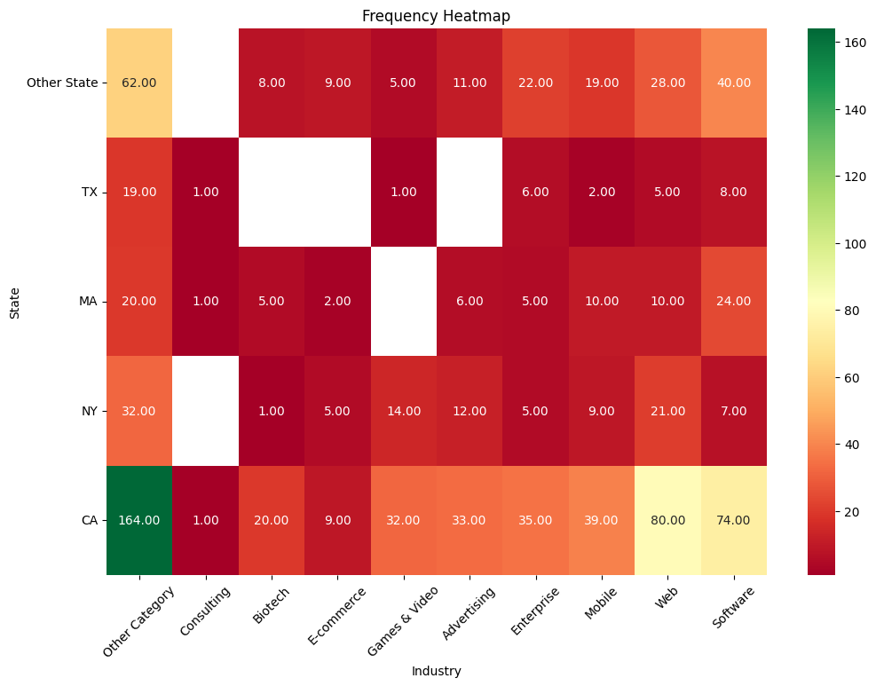

```python
heatmap_data = df.groupby(['is_CA', 'is_NY', 'is_MA', 'is_TX', 'is_otherstate',
                           'is_software', 'is_web', 'is_mobile', 'is_enterprise',
                           'is_advertising', 'is_gamesvideo', 'is_ecommerce',
                           'is_biotech', 'is_consulting', 'is_othercategory']).count().reset_index()

heatmap_data = heatmap_data.pivot_table(index=['is_CA', 'is_NY', 'is_MA', 'is_TX', 'is_otherstate'],
                                        columns=['is_software', 'is_web', 'is_mobile', 'is_enterprise',
                                                 'is_advertising', 'is_gamesvideo', 'is_ecommerce',
                                                 'is_biotech', 'is_consulting', 'is_othercategory'],
                                        values='labels', aggfunc='mean')

state_labels = ['CA', 'NY', 'MA', 'TX', 'Other State'][::-1]
industry_labels = ['Software', 'Web', 'Mobile', 'Enterprise', 'Advertising',
                   'Games & Video', 'E-commerce', 'Biotech', 'Consulting', 'Other Category'][::-1]

plt.figure(figsize=(12, 8))
sns.heatmap(heatmap_data[1:], cmap='RdYlGn', annot=True, fmt=".2f", cbar=True)
plt.title('Frequency Heatmap')
plt.xlabel('Industry')
plt.xticks(ticks=np.arange(len(industry_labels)) + 0.5, labels=industry_labels, rotation=45)
plt.ylabel('State')
plt.yticks(ticks=np.arange(len(state_labels))  + 0.5, labels=state_labels, rotation=0)
plt.show()
```

**It is clear that CA & Other Category are an outlier** as they are skewing the data by having copious amounts of entries, so to get a better look at the rest of the data we remove them and graph again below.

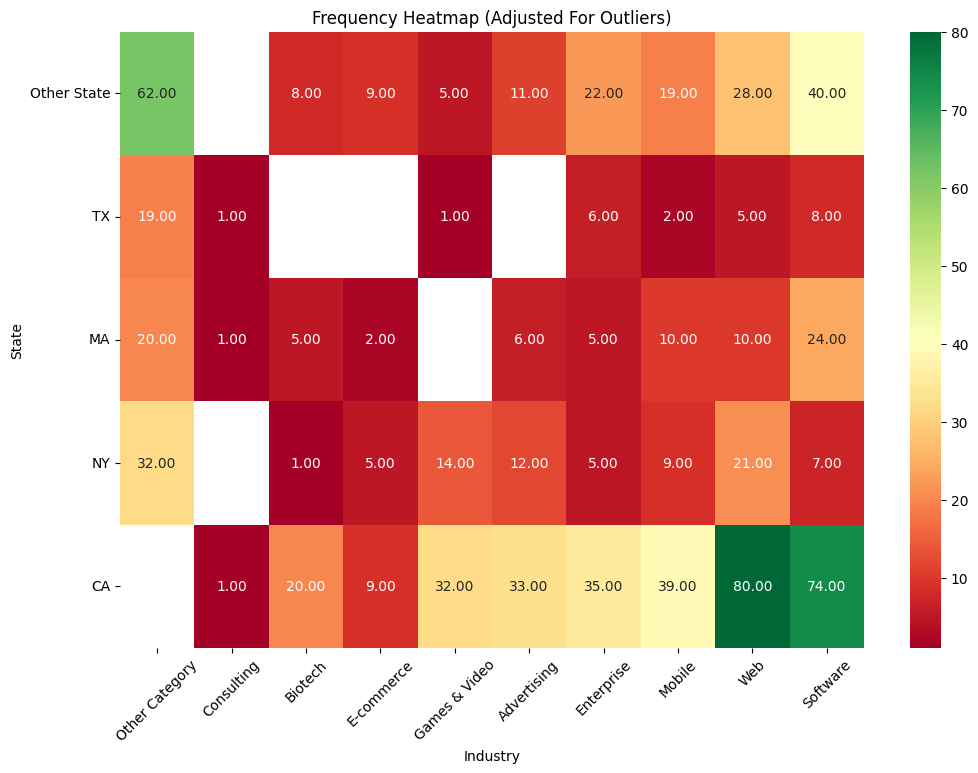

```python
heatmap_data = df[~((df['is_CA'] == 1) & (df['is_othercategory'] == 1))].groupby(['is_CA', 'is_NY', 'is_MA', 'is_TX', 'is_otherstate',
                           'is_software', 'is_web', 'is_mobile', 'is_enterprise',
                           'is_advertising', 'is_gamesvideo', 'is_ecommerce',
                           'is_biotech', 'is_consulting', 'is_othercategory']).count().reset_index()

heatmap_data = heatmap_data.pivot_table(index=['is_CA', 'is_NY', 'is_MA', 'is_TX', 'is_otherstate'],
                                        columns=['is_software', 'is_web', 'is_mobile', 'is_enterprise',
                                                 'is_advertising', 'is_gamesvideo', 'is_ecommerce',
                                                 'is_biotech', 'is_consulting', 'is_othercategory'],
                                        values='labels', aggfunc='mean')

state_labels = ['CA', 'NY', 'MA', 'TX', 'Other State'][::-1]
industry_labels = ['Software', 'Web', 'Mobile', 'Enterprise', 'Advertising',
                   'Games & Video', 'E-commerce', 'Biotech', 'Consulting', 'Other Category'][::-1]

plt.figure(figsize=(12, 8))
sns.heatmap(heatmap_data[1:], cmap='RdYlGn', annot=True, fmt=".2f", cbar=True)
plt.title('Frequency Heatmap (Adjusted For Outliers)')
plt.xlabel('Industry')
plt.xticks(ticks=np.arange(len(industry_labels)) + 0.5, labels=industry_labels, rotation=45)
plt.ylabel('State')
plt.yticks(ticks=np.arange(len(state_labels))  + 0.5, labels=state_labels, rotation=0)
plt.show()
```

**Conclusion:**

There are many combinations that have very few data points (less than 10), so we can't trust the results of them. However there are a decent amount of data points for certain combinations, which we can make conclusions from. Firstly, software in California is pretty succesfull with a .72 average succes rate. NY & Other Category and CA & Enterprise seem to be the categories with the highest success rates (0.80+) while also maintaining a high number of data points (30+).

## **Conclusion 3:**

**Intro**

Another point of interest is the relationship between funding rounds and success.

**Background**

Startups go through 4 main funding rounds: A, B, C, & D. When a startup first goes looking for money after having an initial product they will call it their A round of funding. As the company gets older and/or their product changes they will go for B, C, & D funding rounds. Generally funding rounds are done sequentially (it woud be rare to see a D round after an A round), but there are cases (for example: a long time inbetween funding rounds, pivot in company purpose, etc) that this is done.

**Exploratory Analysis**

Below we try to visualize how many companies succeded based what funding rounds they went through.

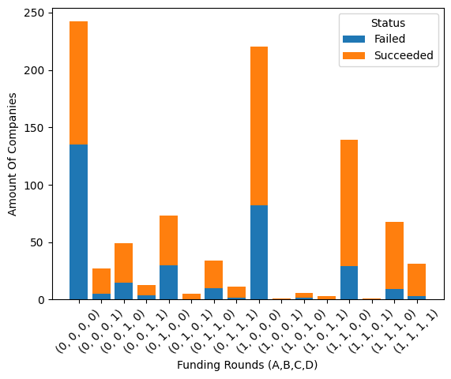

```python
round_columns = ['has_roundA', 'has_roundB', 'has_roundC', 'has_roundD', 'labels']

grouped = df.groupby(round_columns)['labels'].count()
grouped = grouped.unstack().fillna(0)

fig, ax = plt.subplots()

bottom = np.zeros(len(grouped.index))
bars = []
for column in grouped.columns:
    bar = ax.bar([str(index) for index in grouped.index], grouped[column], bottom=bottom, label=column)
    bars.append(bar)
    bottom += grouped[column]

ax.set_ylabel('Amount Of Companies')
ax.set_xlabel('Funding Rounds (A,B,C,D)')

legend_labels = {'0': 'Failed', '1': 'Succeeded'}
handles, labels = ax.get_legend_handles_labels()
new_labels = [legend_labels[label] if label in legend_labels else label for label in labels]
ax.legend(handles, new_labels, title='Status', loc="upper right")
plt.xticks(rotation=45)

plt.show()
```

Some interesting things to notice in this graph are that the bars tend to follow a downward trend as they go the right (inverse relationship between # companies and amount of funding rounds). You can also notice that continous funding rounds (None, A, AB, ABC, ABCD) have the most amount of companies, likely because most companies follow that paradigm.

Below we try to visualize the percent of companies that succeded based what funding rounds they went through.

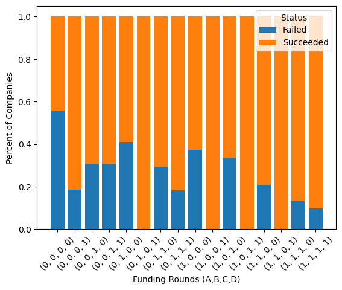

```python
round_columns = ['has_roundA', 'has_roundB', 'has_roundC', 'has_roundD', 'labels']

grouped = df.groupby(round_columns)['labels'].count()

grouped = grouped.unstack().fillna(0)

grouped_normalized = grouped.div(grouped.sum(axis=1), axis=0)

fig, ax = plt.subplots()

bottom = np.zeros(len(grouped_normalized.index))
bars = []
for column in grouped_normalized.columns:
    bar = ax.bar([str(index) for index in grouped_normalized.index], grouped_normalized[column], bottom=bottom, label=column)
    bars.append(bar)
    bottom += grouped_normalized[column]

ax.set_ylabel('Percent of Companies')
ax.set_xlabel('Funding Rounds (A,B,C,D)')

legend_labels = {'0': 'Failed', '1': 'Succeeded'}
handles, labels = ax.get_legend_handles_labels()
new_labels = [legend_labels[label] if label in legend_labels else label for label in labels]
ax.legend(handles, new_labels, title='Status', loc="upper right")
plt.xticks(rotation=45)

plt.show()
```

Some things to note are that the more funding rounds companies get tends to be corelated with how succesful they are.

Below we try to visualize how the average funding companies recieved influenced their success using the funding rounds they went through.

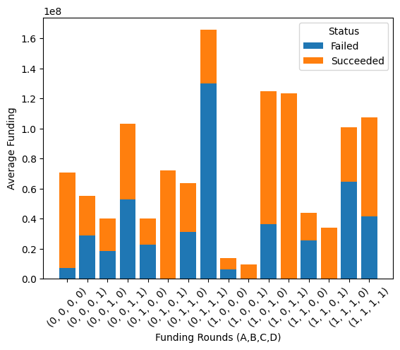

```python
round_columns = ['has_roundA', 'has_roundB', 'has_roundC', 'has_roundD', 'labels']

grouped = df.groupby(round_columns)['funding_total_usd'].mean()
grouped = grouped.unstack().fillna(0)

fig, ax = plt.subplots()

bottom = np.zeros(len(grouped.index))
bars = []
for column in grouped.columns:
    bar = ax.bar([str(index) for index in grouped.index], grouped[column], bottom=bottom, label=column)
    bars.append(bar)
    bottom += grouped[column]

ax.set_ylabel('Average Funding')
ax.set_xlabel('Funding Rounds (A,B,C,D)')

legend_labels = {'0': 'Failed', '1': 'Succeeded'}
handles, labels = ax.get_legend_handles_labels()
new_labels = [legend_labels[label] if label in legend_labels else label for label in labels]
ax.legend(handles, new_labels, title='Status', loc="upper right")
plt.xticks(rotation=45)

plt.show()
```

This graph is less related to the question, but it is still interesting in regards to the question. One can see that (0,1,1,1) could potentially be or have an outlier in the amount of funding recieved. And there doesn't seem to be a corelation between the amount of funding different statups receive and how succesful they are at least not while we account for differences in funding rounds gone through.

**Conclusion:**

Companies that go through all typical rounds of funding (A through D) are more likely to succeed. From conjecture, we conclude that this is likely not due to the money from the funding, but likely due to the fact that companies can only go through all 4 rounds if investors consistently find their company viable over the span of several years. Though we can't say for sure why, there is definetly a correlation between a startup going through all funding rounds and increased chance of success for a startup.

# **Machine Learning Analysis**

For this step of the data-science pipeline, we wanted to construct a ML model that can predict a successful startup and validate our previous data analysis. As a result, we used a variety of different ML models and assessed the effectiveness of the different models. However, we'd like to mention that some other possible ML models that could be applied here is K-Modes to find meaningful features using Clustering or a variation of an Auto-Encoder Neural Network to find the optimal feature set.

Below is the version of the startup dataset that we're going to use for applying these ML models:

```python
df
```

|  | state_code | latitude | longitude | zip_code | id | city | name | labels | founded_at | closed_at | ... | is_consulting | is_othercategory | has_VC | has_angel | has_roundA | has_roundB | has_roundC | has_roundD | avg_participants | is_top500 |
| --- | --- | --- | --- | --- | --- | --- | --- | --- | --- | --- | --- | --- | --- | --- | --- | --- | --- | --- | --- | --- | --- |
| 0 | CA | 42 | -71 | 92101 | 6669 | San Diego | Bandsintown | 1 | 2007-01-01 | NaT | ... | 0 | 1 | 0 | 1 | 0 | 0 | 0 | 0 | 1.0000 | 0 |
| 1 | CA | 37 | -121 | 95032 | 16283 | Los Gatos | TriCipher | 1 | 2000-01-01 | NaT | ... | 0 | 0 | 1 | 0 | 0 | 1 | 1 | 1 | 4.7500 | 1 |
| 2 | CA | 32 | -117 | 92121 | 65620 | San Diego | Plixi | 1 | 2009-03-18 | NaT | ... | 0 | 0 | 0 | 0 | 1 | 0 | 0 | 0 | 4.0000 | 1 |
| 3 | CA | 37 | -122 | 95014 | 42668 | Cupertino | Solidcore Systems | 1 | 2002-01-01 | NaT | ... | 0 | 0 | 0 | 0 | 0 | 1 | 1 | 1 | 3.3333 | 1 |
| 4 | CA | 37 | -122 | 94105 | 65806 | San Francisco | Inhale Digital | 0 | 2010-08-01 | 2012-10-01 | ... | 0 | 0 | 1 | 1 | 0 | 0 | 0 | 0 | 1.0000 | 1 |
| ... | ... | ... | ... | ... | ... | ... | ... | ... | ... | ... | ... | ... | ... | ... | ... | ... | ... | ... | ... | ... | ... |
| 918 | CA | 37 | -122 | 94107 | 21343 | San Francisco | CoTweet | 1 | 2009-01-01 | NaT | ... | 0 | 0 | 0 | 0 | 1 | 0 | 0 | 0 | 6.0000 | 1 |
| 919 | MA | 42 | -71 | 1803 | 41747 | Burlington | Reef Point Systems | 0 | 1998-01-01 | 2008-06-25 | ... | 0 | 1 | 1 | 0 | 0 | 1 | 0 | 0 | 2.6667 | 1 |
| 920 | CA | 37 | -122 | 94089 | 31549 | Sunnyvale | Paracor Medical | 0 | 1999-01-01 | 2012-06-17 | ... | 0 | 0 | 0 | 0 | 0 | 0 | 0 | 1 | 8.0000 | 1 |
| 921 | CA | 37 | -122 | 94404 | 33198 | San Francisco | Causata | 1 | 2009-01-01 | NaT | ... | 0 | 0 | 0 | 0 | 1 | 1 | 0 | 0 | 1.0000 | 1 |
| 922 | CA | 37 | -121 | 95054 | 26702 | Santa Clara | Asempra Technologies | 1 | 2003-01-01 | NaT | ... | 0 | 1 | 0 | 0 | 0 | 1 | 0 | 0 | 3.0000 | 1 |

923 rows × 44 columns

## **K-Means and Principal Component Analysis**

Initially we decided to use an experimental approach to cluster startups based on features. We're interest in exploring the differences in the columns `is_top500` and `labels` in relation to these clusters because they are indicators of success. In other words, we're using K-Means to find groups of startups similar to how in the real world companies would use K-Means to observe properties of customer groups. Furthermore, we used Principal Component Analysis on our K-Means model with the hopes of directly finding what could be the most important feature set for success.

```python
df_km = df
```

### Building the Model - Data Cleaning and Feature Engineering

For data cleaning, we want to deal with NaNs in `age_first_milestone_year` and `age_last_milestone_year`. So, first we check if all NaNs corespond to milestones.

```python
print(df_km[(df_km['age_first_milestone_year'].isna() & df_km['age_last_milestone_year'].isna()) & (df_km['milestones'] == 0)].equals(df_km[df_km['milestones'] == 0]))
```

```
True
```

Thus we need to convert all NaNs to 0 as that makes the most sense in this context.

```python
df_km = df_km.fillna(0)
```

In addition, we want to drop the following columns:

```python
# Drop columns
columns_to_drop = [
  'id',
  'name',
  'city',
  'closed_at',
  'state_code',
  'category_code'
]
df_km = df.drop(columns=columns_to_drop)
```

Now, the feature engineering changes that need to be made are....

Min Max Scale:

- `latitude`
- `longitude`
- `zip_code`
- `founded_at`
- `first_funding_at`
- `last_funding_at`
- `age_first_funding_year`
- `age_last_funding_year`
- `age_first_milestone_year`
- `age_last_milestone_year`
- `relationships`
- `funding_rounds`
- `funding_total_usd`
- `milestones`

```python
# Min-max scale numeric columns
columns_to_scale = [
  'latitude',
  'longitude',
  'zip_code',
  'founded_at',
  'first_funding_at',
  'last_funding_at',
  'age_first_funding_year',
  'age_last_funding_year',
  'age_first_milestone_year',
  'age_last_milestone_year',
  'relationships',
  'funding_rounds',
  'funding_total_usd',
  'milestones'
]

# Convert date-time columns into floats
for col in columns_to_scale:
  if df[col].dtypes == "datetime64[ns]":
    df_km[col] = (df[col] - pd.Timestamp("1970-01-01")) // pd.Timedelta('1s')

df_km = df_km.fillna(0)

scaler = MinMaxScaler()
df_km[columns_to_scale] = scaler.fit_transform(df_km[columns_to_scale])
```

Now let's check that the Min Max Scaling worked:

```python
# print(f"DataType{df_km[columns_to_scale].dtypes}")
for col in columns_to_scale:
  print(f"{col.ljust(24)} | {df_km[col].dtype} | [{df_km[col].min()} , {df_km[col].max()}] | NaNs: {df_km[col].isna().sum()}")
```

```
latitude                 | float64 | [0.0 , 1.0] | NaNs: 0
longitude                | float64 | [0.0 , 1.0] | NaNs: 0
zip_code                 | float64 | [0.0 , 1.0] | NaNs: 0
founded_at               | float64 | [0.0 , 1.0] | NaNs: 0
first_funding_at         | float64 | [0.0 , 1.0] | NaNs: 0
last_funding_at          | float64 | [0.0 , 1.0] | NaNs: 0
age_first_funding_year   | float64 | [0.0 , 1.0] | NaNs: 0
age_last_funding_year    | float64 | [0.0 , 1.0] | NaNs: 0
age_first_milestone_year | float64 | [0.0 , 1.0] | NaNs: 0
age_last_milestone_year  | float64 | [0.0 , 1.0] | NaNs: 0
relationships            | float64 | [0.0 , 1.0] | NaNs: 0
funding_rounds           | float64 | [0.0 , 1.0] | NaNs: 0
funding_total_usd        | float64 | [0.0 , 1.0] | NaNs: 0
milestones               | float64 | [0.0 , 1.0] | NaNs: 0
```

### Finding the best K value via Elbow Method for K-Means

```python
df_km
```

|  | latitude | longitude | zip_code | labels | founded_at | first_funding_at | last_funding_at | age_first_funding_year | age_last_funding_year | age_first_milestone_year | ... | is_consulting | is_othercategory | has_VC | has_angel | has_roundA | has_roundB | has_roundC | has_roundD | avg_participants | is_top500 |
| --- | --- | --- | --- | --- | --- | --- | --- | --- | --- | --- | --- | --- | --- | --- | --- | --- | --- | --- | --- | --- | --- |
| 0 | 0.500000 | 0.364286 | 0.097874 | 1 | 0.785287 | 0.666009 | 0.698470 | 0.365061 | 0.389409 | 0.484841 | ... | 0 | 1 | 0 | 1 | 0 | 0 | 0 | 0 | 1.0000 | 0 |
| 1 | 0.352941 | 0.007143 | 0.100989 | 1 | 0.546270 | 0.368888 | 0.697620 | 0.458030 | 0.615461 | 0.544988 | ... | 0 | 0 | 1 | 0 | 0 | 1 | 1 | 1 | 4.7500 | 1 |
| 2 | 0.205882 | 0.035714 | 0.097895 | 1 | 0.860722 | 0.737579 | 0.717170 | 0.325749 | 0.325749 | 0.402200 | ... | 0 | 0 | 0 | 0 | 1 | 0 | 0 | 0 | 4.0000 | 1 |
| 3 | 0.352941 | 0.000000 | 0.100969 | 1 | 0.614601 | 0.369479 | 0.489800 | 0.393572 | 0.464142 | 0.519179 | ... | 0 | 0 | 0 | 0 | 0 | 1 | 1 | 1 | 3.3333 | 1 |
| 4 | 0.352941 | 0.000000 | 0.100004 | 0 | 0.907553 | 0.762027 | 0.872928 | 0.292368 | 0.346291 | 0.365677 | ... | 0 | 0 | 1 | 1 | 0 | 0 | 0 | 0 | 1.0000 | 1 |
| ... | ... | ... | ... | ... | ... | ... | ... | ... | ... | ... | ... | ... | ... | ... | ... | ... | ... | ... | ... | ... | ... |
| 918 | 0.352941 | 0.000000 | 0.100006 | 1 | 0.853617 | 0.685528 | 0.661071 | 0.309102 | 0.309102 | 0.379636 | ... | 0 | 0 | 0 | 0 | 1 | 0 | 0 | 0 | 6.0000 | 1 |
| 919 | 0.500000 | 0.364286 | 0.001916 | 0 | 0.478033 | 0.377957 | 0.482788 | 0.526742 | 0.590579 | 0.519179 | ... | 0 | 1 | 1 | 0 | 0 | 1 | 0 | 0 | 2.6667 | 1 |
| 920 | 0.352941 | 0.000000 | 0.099987 | 0 | 0.512152 | 0.539432 | 0.503612 | 0.566939 | 0.566939 | 0.596462 | ... | 0 | 0 | 0 | 0 | 0 | 0 | 0 | 1 | 8.0000 | 1 |
| 921 | 0.352941 | 0.000000 | 0.100321 | 1 | 0.853617 | 0.702879 | 0.840629 | 0.316894 | 0.383922 | 0.384220 | ... | 0 | 0 | 0 | 0 | 1 | 1 | 0 | 0 | 1.0000 | 1 |
| 922 | 0.352941 | 0.007143 | 0.101012 | 1 | 0.648719 | 0.440655 | 0.397153 | 0.393216 | 0.393216 | 0.467705 | ... | 0 | 1 | 0 | 0 | 0 | 1 | 0 | 0 | 3.0000 | 1 |

923 rows × 38 columns

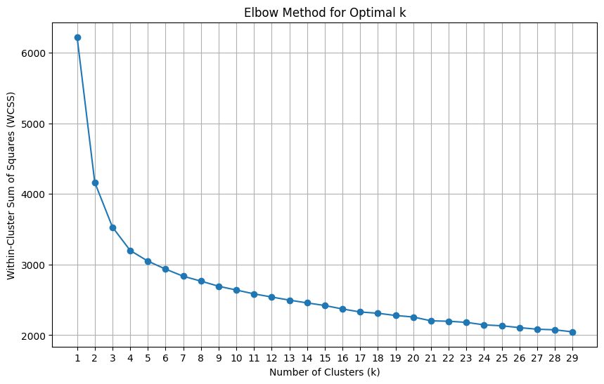

```python
wcss = []
labels_lst = []
is_top500_lst = []
num_ks = 30
for k in range(1, num_ks):
    kmeans = KMeans(n_clusters=k, n_init=20, random_state=42)
    kmeans.fit(df_km)
    wcss.append(kmeans.inertia_)

    # cluster_labels = kmeans.labels_
    # df_km['cluster'] = cluster_labels
    # cluster_means = df_km.groupby('cluster')['labels'].mean()

# Plot the elbow curve
plt.figure(figsize=(10, 6))
plt.plot(range(1, num_ks), wcss, marker='o', linestyle='-')
plt.title('Elbow Method for Optimal k')
plt.xlabel('Number of Clusters (k)')
plt.ylabel('Within-Cluster Sum of Squares (WCSS)')
plt.xticks(np.arange(1, num_ks, 1))
plt.grid(True)
plt.show()
```

From visual inspection, we can see that the optimal k value is 4.

### Performing K-Means, Analyzing the Inter-Cluster Distance, and Hypothesis Testing

After performing K-Means, we wanted to observe the inter-cluster distance to find the features the data varied the most in. The features with the largest inter-cluster distances (i.e. ranges) indicate the best features for seperating clusters. These are important in determining the success of the clusters.

```python
# Fit KMeans with optimal k
optimal_k = 4
kmeans = KMeans(n_clusters=optimal_k, n_init=20, random_state=42)
kmeans.fit(df_km)

# Get cluster centroids
centroids = kmeans.cluster_centers_

# Create DataFrame to store centroids
centroids_df = pd.DataFrame(centroids, columns=df_km.columns)

column_ranges = centroids_df.apply(lambda col: col.max() - col.min())

top_n = 12

# Sort the column ranges in descending order
sorted_ranges = column_ranges.sort_values(ascending=False)

# Get the top x columns with the largest range
top_x_columns = sorted_ranges.head(top_n)

# Print the top x columns with the largest range
print(f"Top {top_n} columns with the largest range:")
print(top_x_columns)
```

```
Top 12 columns with the largest range:
avg_participants    7.220286
has_roundB          0.509211
is_top500           0.487408
labels              0.339136
has_roundA          0.302153
has_roundC          0.300909
has_angel           0.257290
has_roundD          0.222940
is_otherstate       0.211609
is_CA               0.207310
is_web              0.170096
has_VC              0.148086
dtype: float64
```

Let's make some graphs for two reasons:

- Are there differences between the success rate of the clusters?
- Sanity check to make sure the cluster values `is_top500` and `labels` columns are roughly the same

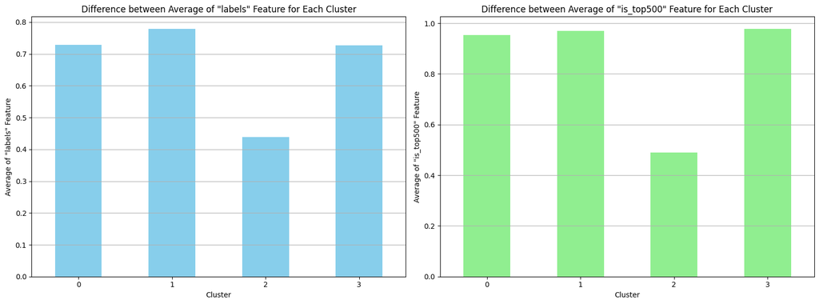

```python
# Get cluster labels for each data point
cluster_labels = kmeans.labels_

# Add cluster labels to the original DataFrame
df_km['cluster'] = cluster_labels

# Calculate the mean of the 'labels' feature for each cluster
cluster_means = df_km.groupby('cluster')['labels'].mean()

# Calculate the mean of the 'is_top500' feature for each cluster
top500_means = df_km.groupby('cluster')['is_top500'].mean()

# Plot both 'labels' and 'is_top500' features in separate bar charts side by side
fig, (ax1, ax2) = plt.subplots(1, 2, figsize=(16, 6))

# Plot 'labels' feature
cluster_means.plot(kind='bar', color='skyblue', ax=ax1)
ax1.set_title('Difference between Average of "labels" Feature for Each Cluster')
ax1.set_xlabel('Cluster')
ax1.set_ylabel('Average of "labels" Feature')
ax1.set_xticks(range(len(cluster_means)))
ax1.set_xticklabels(cluster_means.index, rotation=0)
ax1.grid(axis='y')

# Plot 'is_top500' feature
top500_means.plot(kind='bar', color='lightgreen', ax=ax2)
ax2.set_title('Difference between Average of "is_top500" Feature for Each Cluster')
ax2.set_xlabel('Cluster')
ax2.set_ylabel('Average of "is_top500" Feature')
ax2.set_xticks(range(len(top500_means)))
ax2.set_xticklabels(top500_means.index, rotation=0)
ax2.grid(axis='y')

plt.tight_layout()
plt.show()
```

There's a clear difference between the success of the clusters but roughly the charts are similar for the two columns.

Let's investigate this more with a T-Test for each individual cluster to determine if the variance between the clusters is statistically significant. So the hypothesis testing for each individual cluster is:

**H0:** The population mean of success for the clusters is the same as the sample mean of success

**Ha:** he population mean of success for the clusters is *not* the same as the sample mean of success

*Running a T-Test on the cluster `labels` variation*

```python
# Calculate the overall mean of the 'labels' feature
overall_mean = df_km['labels'].mean()

# Perform t-test for each cluster mean against the overall mean
for cluster, mean in cluster_means.items():
    t_statistic, p_value = ttest_ind(df_km[df_km['cluster'] == cluster]['labels'],
                                      df_km['labels'],
                                      equal_var=False)
    print(f"Cluster {cluster} vs. Overall Mean:")
    print(f"T-statistic: {t_statistic:<6.2f} | P-value: {p_value:.2e}")
    if p_value < 0.05:
        print("REJECT null hypothesis: significant difference.\n")
    else:
        print("FAIL to reject null hypothesis: NO significant difference.\n")
```

```
Cluster 0 vs. Overall Mean:
T-statistic: 2.96   | P-value: 3.15e-03
REJECT null hypothesis: significant difference.

Cluster 1 vs. Overall Mean:
T-statistic: 3.96   | P-value: 9.11e-05
REJECT null hypothesis: significant difference.

Cluster 2 vs. Overall Mean:
T-statistic: -6.31  | P-value: 6.34e-10
REJECT null hypothesis: significant difference.

Cluster 3 vs. Overall Mean:
T-statistic: 1.15   | P-value: 2.54e-01
FAIL to reject null hypothesis: NO significant difference.
```

*Run a T-Test on the cluster `is_top500` variation*

```python
# Calculate the overall mean of the 'labels' feature
overall_mean = df_km['is_top500'].mean()

# Perform t-test for each cluster mean against the overall mean
for cluster, mean in cluster_means.items():
    t_statistic, p_value = ttest_ind(df_km[df_km['cluster'] == cluster]['is_top500'],
                                      df_km['is_top500'],
                                      equal_var=False)
    print(f"Cluster {cluster} vs. Overall Mean:")
    print(f"T-statistic: {t_statistic:<6.2f} | P-value: {p_value:.2e}")
    if p_value < 0.05:
        print("REJECT null hypothesis: significant difference.\n")
    else:
        print("FAIL to reject null hypothesis: NO significant difference.\n")
```

```
Cluster 0 vs. Overall Mean:
T-statistic: 8.47   | P-value: 7.15e-17
REJECT null hypothesis: significant difference.

Cluster 1 vs. Overall Mean:
T-statistic: 9.16   | P-value: 5.05e-19
REJECT null hypothesis: significant difference.

Cluster 2 vs. Overall Mean:
T-statistic: -10.03 | P-value: 2.35e-21
REJECT null hypothesis: significant difference.

Cluster 3 vs. Overall Mean:
T-statistic: 6.42   | P-value: 1.10e-08
REJECT null hypothesis: significant difference.
```

Interestingly, cluster 3 was NOT statistically significant for the `labels` column but it was for the `is_top500` column. However, we'll still be using cluster 3 as a metric of success as it was statistically significant for one column even if both weren't.

Now let's graph the features with the highest range in order of the cluster success to see what the correlation is between success and that feature is.

```
Index(['avg_participants', 'has_roundB', 'has_roundA', 'has_roundC',
       'has_angel', 'has_roundD', 'is_otherstate', 'is_CA', 'is_web',
       'has_VC'],
      dtype='object')
```

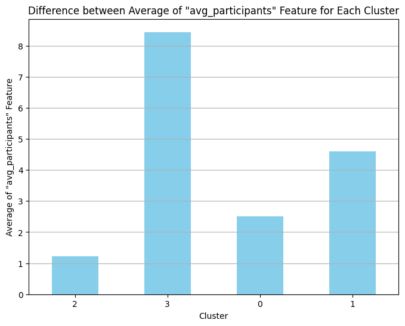

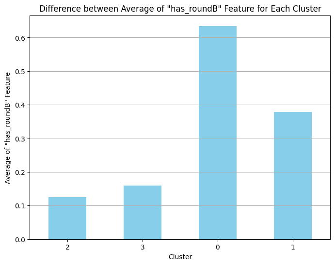

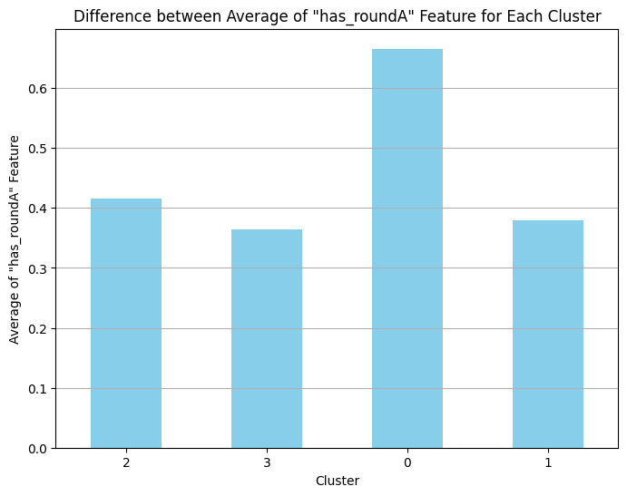

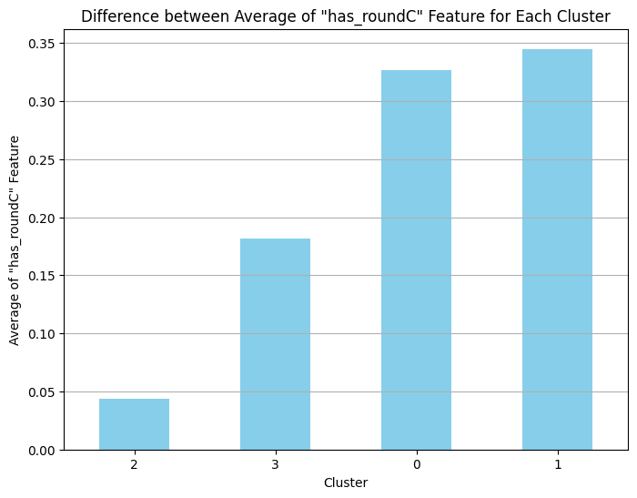

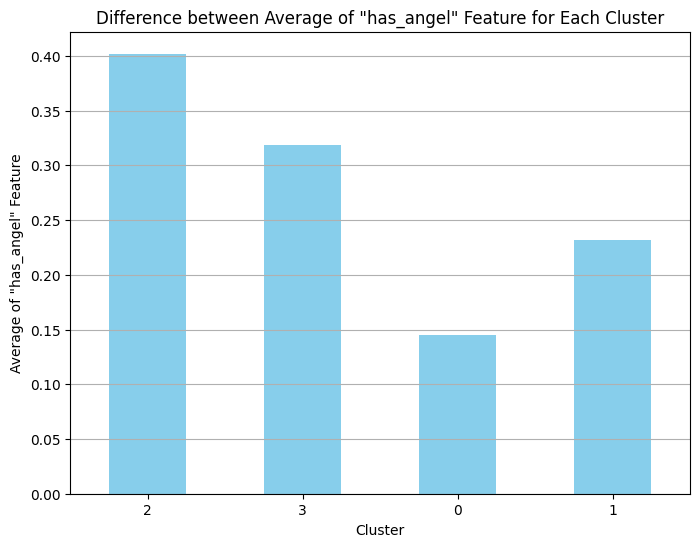

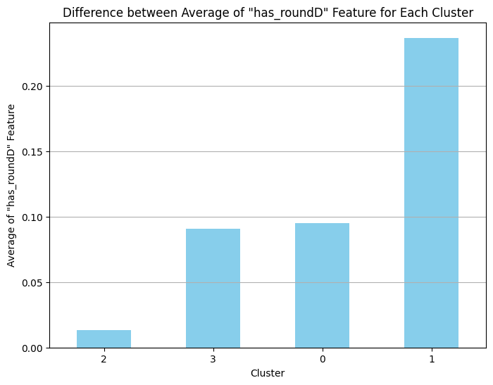

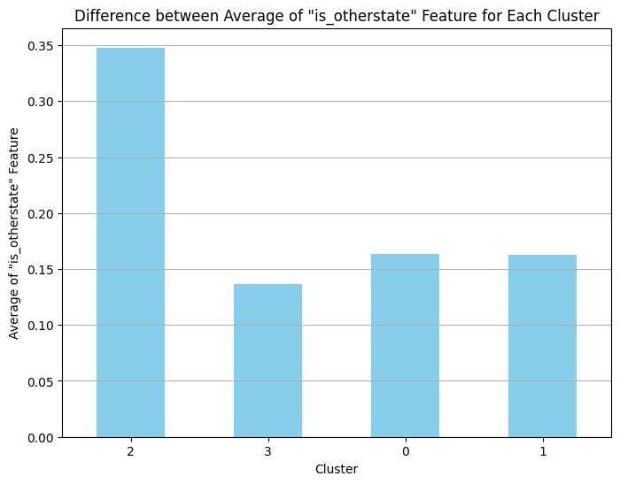

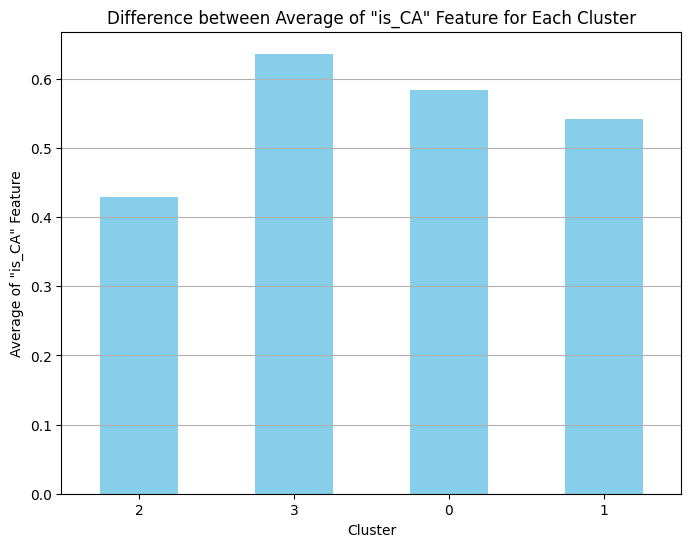

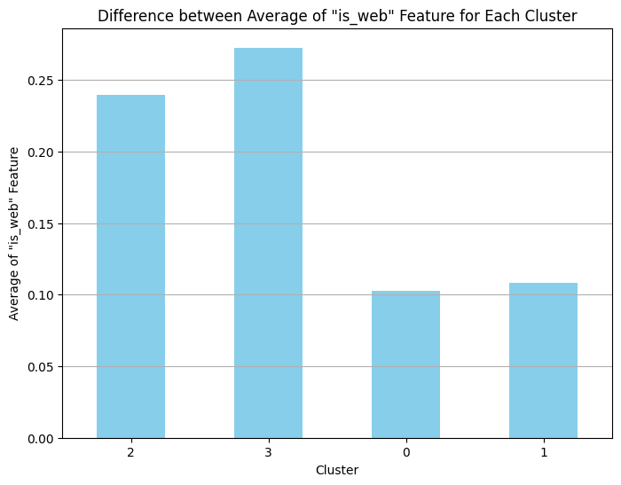

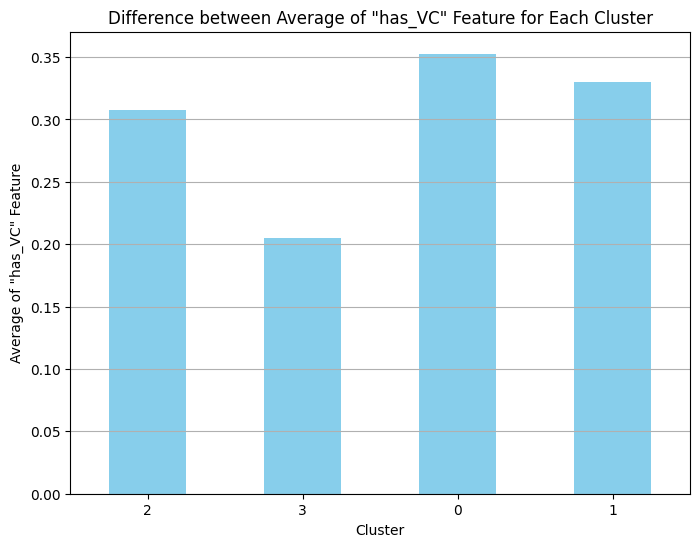

```python
columns_to_plot = top_x_columns.index

if 'is_top500' in columns_to_plot:
  columns_to_plot = columns_to_plot.drop('is_top500')
if 'labels' in columns_to_plot:
  columns_to_plot = columns_to_plot.drop('labels')

print(columns_to_plot)

for col in columns_to_plot:
  # Calculate the mean of the 'labels' feature for each cluster and sort clusters by it
  sorted_clusters = df_km.groupby('cluster')['labels'].mean().sort_values().index

  # Calculate the mean of the feature 'col' for each cluster
  cluster_means = df_km.groupby('cluster')[col].mean()

  # Plot the difference between cluster means with bars sorted based on mean 'labels' values
  plt.figure(figsize=(8, 6))
  cluster_means.reindex(sorted_clusters).plot(kind='bar', color='skyblue')
  plt.title(f'Difference between Average of "{col}" Feature for Each Cluster')
  plt.xlabel('Cluster')
  plt.ylabel(f'Average of "{col}" Feature')
  plt.xticks(rotation=0)
  plt.grid(axis='y')
  plt.show()
```

Based on the graphs it seems that the average number of participants (founders and employees) in a startup is the most important measure of success. Where 1 participant indicates likely failure, 4-5 is optimal, and 2-3 have the same chance as 8-9.

After further discussion with TA, we decided not to go further with K-Means due to an incompatibility between the dataset and the ML model though the findings are interesting.

### Performing Principal Component Analysis

Let's perform PCA and determine the meaningful features by converting the features into the 12 principal components with highest variance. We'll use our K-Means dataset since it's already in the correct format.

```python
df_pca_og = df_km.drop(columns=['cluster'])

pca = PCA(n_components=12)
pca.fit(df_pca_og)
X_pca = pca.transform(df_pca_og)

component_names = [f"PC{i+1}" for i in range(X_pca.shape[1])]
df_pca = pd.DataFrame(data=X_pca, columns=component_names)
df_pca
```

|  | PC1 | PC2 | PC3 | PC4 | PC5 | PC6 | PC7 | PC8 | PC9 | PC10 | PC11 | PC12 |
| --- | --- | --- | --- | --- | --- | --- | --- | --- | --- | --- | --- | --- |
| 0 | -1.844068 | 0.462758 | -0.776709 | 0.576044 | 0.566325 | -0.754774 | 0.325448 | -0.224508 | -0.177359 | -0.236098 | -0.034412 | 0.010508 |
| 1 | 2.006690 | -0.839082 | 0.590729 | 0.644295 | -0.711079 | -0.526724 | 0.213255 | 0.535420 | -0.299839 | 0.170329 | -0.215556 | 0.388600 |
| 2 | 1.174615 | -0.225064 | -0.928827 | -0.350800 | -0.216450 | 0.094761 | -0.418287 | -0.216541 | -0.188058 | 0.619893 | 0.387988 | -0.171344 |
| 3 | 0.604317 | -0.949708 | 0.249815 | 0.374492 | -0.674660 | -0.216675 | 1.170225 | -0.306747 | -0.006466 | 0.036357 | -0.160501 | -0.170509 |
| 4 | -1.862314 | 0.535952 | -0.434521 | 0.725118 | -0.595943 | -0.304507 | -0.341908 | 0.536716 | 0.167540 | -0.516694 | -0.317668 | -0.128559 |
| ... | ... | ... | ... | ... | ... | ... | ... | ... | ... | ... | ... | ... |
| 918 | 3.163511 | -0.175142 | -0.750116 | -0.283592 | -0.139519 | 0.231962 | -0.379976 | -0.400073 | -0.055286 | 0.129921 | -0.210928 | 0.493185 |
| 919 | -0.178783 | 0.149388 | 1.073682 | 0.598169 | 0.329528 | 0.220668 | -0.084709 | 0.339156 | 0.626481 | -0.398130 | 0.705304 | -0.249574 |
| 920 | 5.161809 | 0.548622 | -0.361580 | 0.574980 | -0.580354 | 0.594735 | 0.334562 | -0.012102 | 0.075996 | 0.289376 | -0.063519 | 0.382933 |
| 921 | -1.797208 | -1.056617 | -0.323219 | -0.267759 | -0.335881 | 0.240999 | 0.147309 | -0.592696 | 0.026206 | -0.550314 | 0.108263 | -0.139845 |
| 922 | 0.233010 | -0.487018 | -0.130425 | 0.671921 | 0.497278 | -0.129177 | 0.368267 | -0.272072 | -0.186000 | -0.372211 | 0.708491 | 0.231730 |

923 rows × 12 columns

```python
# Get the PCA components
pca_components = pca.components_

# Create a DataFrame to visualize the PCA components with original feature names
df_pca_components = pd.DataFrame(pca_components, columns=df_pca_og.columns, index=component_names)

# Display the DataFrame
print("PCA Components with Original Feature Names:")
print(df_pca_components)
```

```
PCA Components with Original Feature Names:
      latitude  longitude  zip_code    labels  founded_at  first_funding_at  \
PC1  -0.001415  -0.004455  0.000061  0.052078   -0.006435         -0.002471
PC2   0.027657   0.081436 -0.017035 -0.337491    0.042077          0.104072
PC3   0.056936   0.122157 -0.030956  0.001370   -0.080901         -0.083681
PC4  -0.057045  -0.133661  0.032843 -0.247479   -0.053735         -0.012699
PC5   0.017726   0.057406 -0.007758  0.075105    0.031461          0.026254
PC6  -0.018579  -0.046826  0.014865 -0.686741   -0.033772         -0.032638
PC7   0.003373   0.025272 -0.010190 -0.077028   -0.044171         -0.070304
PC8  -0.005173   0.021238 -0.011154 -0.426281    0.055042          0.003768
PC9  -0.005722   0.143255 -0.044625 -0.252455   -0.007404         -0.008338
PC10 -0.007722   0.006886  0.000868  0.044065   -0.054944         -0.059444
PC11  0.019729   0.017275 -0.008805  0.108690   -0.035714         -0.012178
PC12 -0.000460  -0.001756 -0.000558  0.120782    0.000611          0.068138

      last_funding_at  age_first_funding_year  age_last_funding_year  \
PC1          0.001448                0.004986               0.006699
PC2          0.007649                0.006881              -0.036669
PC3         -0.005321                0.039051               0.074414
PC4         -0.019551                0.045196               0.042752
PC5          0.017020               -0.018010              -0.022708
PC6         -0.077873                0.017333              -0.000458
PC7         -0.097140                0.010267               0.001364
PC8          0.126607               -0.050445               0.000617
PC9         -0.027218                0.003269              -0.004328
PC10        -0.086984                0.025349               0.015800
PC11        -0.100873                0.028361              -0.008203
PC12        -0.008134                0.030020              -0.003969

      age_first_milestone_year  ...  is_consulting  is_othercategory  \
PC1                   0.002477  ...      -0.000894          0.022636
PC2                  -0.032912  ...      -0.002690          0.026472
PC3                   0.021212  ...       0.003647          0.097502
PC4                  -0.001881  ...      -0.000199          0.428798
PC5                  -0.008666  ...      -0.002332          0.765850
PC6                  -0.016518  ...      -0.001782         -0.006088
PC7                   0.004015  ...      -0.002931         -0.060150
PC8                  -0.019374  ...       0.001872         -0.116217
PC9                  -0.012166  ...       0.007109         -0.019829
PC10                  0.015845  ...       0.008127         -0.061955
```

[output cut: 17 more lines]

```
      avg_participants  is_top500
PC1           0.993338   0.073335
PC2           0.067280  -0.273493
PC3          -0.005943   0.138252
PC4          -0.024161  -0.016746
PC5          -0.020352   0.034556
PC6           0.059986  -0.102563
PC7          -0.014034  -0.137537
PC8           0.018152  -0.041008
PC9          -0.008358   0.007163
PC10         -0.010709  -0.154598
PC11          0.001171   0.002009
PC12          0.014077  -0.291025

[12 rows x 38 columns]
```

```python
# Define the number of top features you want to retrieve
top_n = 5

# Get the absolute values of the PCA components
abs_pca_components = np.abs(pca.components_)

top_features = {}

# Iterate over each principal component
for i, pc in enumerate(abs_pca_components):
    # Get the indices of the top n features that contribute the most to the current principal component
    top_indices = np.argsort(pc)[-top_n:][::-1]

    # Get the corresponding feature names
    top_feature_names = [df_pca_og.columns[index] for index in top_indices]

    for feature in top_feature_names:
      if feature in top_features:
        top_features[feature] += 1
      else:
        top_features[feature] = 1

    # Print the top feature names for the current principal component
    print(f"Top {top_n} features contributing to PC{i+1}: {top_feature_names}")

# Sort the top_features dictionary by count (value) in descending order
sorted_top_features = sorted(top_features.items(), key=lambda x: x[1], reverse=True)

print("-"*50)
print("Counts of Features:")
for feature, count in sorted_top_features[:10]:
  print(f"{count} : {feature}")
```

```
Top 5 features contributing to PC1: ['avg_participants', 'is_top500', 'labels', 'has_roundC', 'is_otherstate']
Top 5 features contributing to PC2: ['has_roundB', 'has_roundA', 'labels', 'is_CA', 'has_angel']
Top 5 features contributing to PC3: ['is_CA', 'has_VC', 'is_otherstate', 'has_angel', 'has_roundC']
Top 5 features contributing to PC4: ['is_CA', 'has_roundA', 'is_othercategory', 'has_VC', 'labels']
Top 5 features contributing to PC5: ['is_othercategory', 'is_software', 'has_VC', 'has_roundA', 'is_CA']
Top 5 features contributing to PC6: ['labels', 'has_roundA', 'has_angel', 'is_otherstate', 'is_NY']
Top 5 features contributing to PC7: ['has_VC', 'has_roundA', 'has_roundC', 'has_roundB', 'is_software']
Top 5 features contributing to PC8: ['is_software', 'labels', 'has_roundB', 'has_angel', 'has_roundC']
Top 5 features contributing to PC9: ['is_otherstate', 'is_NY', 'is_MA', 'labels', 'is_CA']
Top 5 features contributing to PC10: ['is_web', 'has_roundB', 'has_roundC', 'has_angel', 'is_software']
Top 5 features contributing to PC11: ['is_web', 'has_roundC', 'has_roundB', 'has_roundA', 'has_angel']
Top 5 features contributing to PC12: ['is_web', 'is_software', 'has_angel', 'is_top500', 'is_enterprise']
--------------------------------------------------
Counts of Features:
7 : has_angel
6 : labels
6 : has_roundC
6 : has_roundA
5 : has_roundB
5 : is_CA
5 : is_software
4 : is_otherstate
4 : has_VC
3 : is_web
```

From the twelve PCs components, we took the top 5 features used in the PCA and then counted how many times a feature showed up within that set of features across all twelve PCs. As we can see, the angel investor has the greatest count within the top 5 features.

## **Decision Tree**

Here, we're using a Decision Tree ML model and extracting the features that yield the highest prediction accuracy.

### Building the Model - Data Cleaning and Feature Engineering:

```python
df_dt = df
```

#### Deal with NaNs in `age_first_milestone_year` and `age_last_milestone_year`

Check if All NaNs Corespond to milestones = 0

```python
print(df_dt[(df_dt['age_first_milestone_year'].isna() & df_dt['age_last_milestone_year'].isna()) & (df_dt['milestones'] == 0)].equals(df_dt[df_dt['milestones'] == 0]))
```

```
True
```

Thus we need to convert all NaNs to 0 as that makes the most sense in this context.

```python
df_dt = df_dt.fillna(0)
```

#### Conversions for One Hots:

```python
# Drop columns
columns_to_drop = [
  'id',
  'name',
  'closed_at',
  'state_code',
  'category_code'
]
df_dt = df_dt.drop(columns=columns_to_drop)

# Create one-hot encoding for `city` column
df_dt = pd.get_dummies(df_dt, columns=['city'], prefix='is_city')

df_dt = df_dt.fillna(0)
```

#### Convert date-time columns into floats (As date-times don't work with sklearn's decision tree)

```python
for col in df_dt.columns:
  if df_dt[col].dtypes == "datetime64[ns]":
    df_dt[col] = (df_dt[col] - pd.Timestamp("1970-01-01")) // pd.Timedelta('1s')
```

```python
columns_to_floatify = [
  'age_first_funding_year',
  'age_last_funding_year',
  'age_first_milestone_year',
  'age_last_milestone_year'
]
for col in columns_to_floatify:
  print(f"{col.ljust(24)} | {df_dt[col].dtype} | [{df_dt[col].min():.2f} , {df_dt[col].max():.2f}] | NaNs: {df_dt[col].isna().sum()}")
```

```
age_first_funding_year   | float64 | [-9.05 , 21.90] | NaNs: 0
age_last_funding_year    | float64 | [-9.05 , 21.90] | NaNs: 0
age_first_milestone_year | float64 | [-14.17 , 24.68] | NaNs: 0
age_last_milestone_year  | float64 | [-7.01 , 24.68] | NaNs: 0
```

Now we have a dataset ready for building a Decision Tree!

```python
df_dt
```

|  | latitude | longitude | zip_code | labels | founded_at | first_funding_at | last_funding_at | age_first_funding_year | age_last_funding_year | age_first_milestone_year | ... | is_city_Westford | is_city_Weston | is_city_Westport | is_city_Williamstown | is_city_Wilmington | is_city_Woburn | is_city_Woodbury | is_city_Yardley | is_city_Yorba Linda | is_city_Zeeland |
| --- | --- | --- | --- | --- | --- | --- | --- | --- | --- | --- | --- | --- | --- | --- | --- | --- | --- | --- | --- | --- | --- |
| 0 | 42 | -71 | 92101 | 1 | 1167609600 | 1238544000 | 1262304000 | 2.2493 | 3.0027 | 4.6685 | ... | False | False | False | False | False | False | False | False | False | False |
| 1 | 37 | -121 | 95032 | 1 | 946684800 | 1108339200 | 1261958400 | 5.1260 | 9.9973 | 7.0055 | ... | False | False | False | False | False | False | False | False | False | False |
| 2 | 32 | -117 | 92121 | 1 | 1237334400 | 1269907200 | 1269907200 | 1.0329 | 1.0329 | 1.4575 | ... | False | False | False | False | False | False | False | False | False | False |
| 3 | 37 | -122 | 95014 | 1 | 1009843200 | 1108598400 | 1177459200 | 3.1315 | 5.3151 | 6.0027 | ... | False | False | False | False | False | False | False | False | False | False |
| 4 | 37 | -122 | 94105 | 0 | 1280620800 | 1280620800 | 1333238400 | 0.0000 | 1.6685 | 0.0384 | ... | False | False | False | False | False | False | False | False | False | False |
| ... | ... | ... | ... | ... | ... | ... | ... | ... | ... | ... | ... | ... | ... | ... | ... | ... | ... | ... | ... | ... | ... |
| 918 | 37 | -122 | 94107 | 1 | 1230768000 | 1247097600 | 1247097600 | 0.5178 | 0.5178 | 0.5808 | ... | False | False | False | False | False | False | False | False | False | False |
| 919 | 42 | -71 | 1803 | 0 | 883612800 | 1112313600 | 1174608000 | 7.2521 | 9.2274 | 6.0027 | ... | False | False | False | False | False | False | False | False | False | False |
| 920 | 37 | -122 | 94089 | 0 | 915148800 | 1183075200 | 1183075200 | 8.4959 | 8.4959 | 9.0055 | ... | False | False | False | False | False | False | False | False | False | False |
| 921 | 37 | -122 | 94404 | 1 | 1230768000 | 1254700800 | 1320105600 | 0.7589 | 2.8329 | 0.7589 | ... | False | False | False | False | False | False | False | False | False | False |
| 922 | 37 | -121 | 95054 | 1 | 1041379200 | 1139788800 | 1139788800 | 3.1205 | 3.1205 | 4.0027 | ... | False | False | False | False | False | False | False | False | False | False |

923 rows × 259 columns

### Training and Testing the Decision Tree

```python
X = df_dt.drop(['labels','is_top500'], axis=1)  # Features
y = df_dt['labels']  # Target variable

# Splitting the data into train and test sets
X_train, X_test, y_train, y_test = train_test_split(X, y, test_size=0.2, random_state=42)

# Creating the decision tree model
clf = DecisionTreeClassifier(max_depth=4)
clf.fit(X_train, y_train)

# Making predictions
y_pred = clf.predict(X_test)

# Evaluating the model
accuracy = accuracy_score(y_test, y_pred)
print("Accuracy:", accuracy)
```

```
Accuracy: 0.772972972972973
```

```python
tree_rules = export_text(clf, feature_names=list(X.columns))
print(tree_rules)
```

```
|--- age_last_milestone_year <= 1.61
|   |--- funding_total_usd <= 12275000.00
|   |   |--- relationships <= 3.50
|   |   |   |--- is_city_Lexington <= 0.50
|   |   |   |   |--- class: 0
|   |   |   |--- is_city_Lexington >  0.50
|   |   |   |   |--- class: 1
|   |   |--- relationships >  3.50
|   |   |   |--- age_first_milestone_year <= 0.31
|   |   |   |   |--- class: 0
|   |   |   |--- age_first_milestone_year >  0.31
|   |   |   |   |--- class: 1
|   |--- funding_total_usd >  12275000.00
|   |   |--- age_first_funding_year <= 7.70
|   |   |   |--- relationships <= 0.50
|   |   |   |   |--- class: 0
|   |   |   |--- relationships >  0.50
|   |   |   |   |--- class: 1
|   |   |--- age_first_funding_year >  7.70
|   |   |   |--- class: 0
|--- age_last_milestone_year >  1.61
|   |--- founded_at <= 936100800.00
|   |   |--- class: 0
|   |--- founded_at >  936100800.00
|   |   |--- relationships <= 8.50
|   |   |   |--- founded_at <= 1056326400.00
|   |   |   |   |--- class: 1
|   |   |   |--- founded_at >  1056326400.00
|   |   |   |   |--- class: 1
|   |   |--- relationships >  8.50
|   |   |   |--- founded_at <= 1281960000.00
|   |   |   |   |--- class: 1
|   |   |   |--- founded_at >  1281960000.00
|   |   |   |   |--- class: 0
```

In our analysis of the decision tree, we should ignore certain features about each startup. We want to see what features are present at the start of the company and not a side effect of the final startup state.

### Calculating Entropy

```python
# Assuming df is your DataFrame
entropies = {}
for column in X.columns:
    feature_values = X[column].value_counts(normalize=True)
    entropies[column] = entropy(feature_values)

# Sort the entropies dictionary by values (entropy values) in descending order
sorted_entropies = sorted(entropies.items(), key=lambda x: x[1], reverse=True)

# Print the top 5 features with the highest entropy
print("Top features with the highest entropy:")
for feature, entropy_value in sorted_entropies[:10]:
    print(f" {entropy_value:.2f} | {feature}")
```

```
Top features with the highest entropy:
 6.53 | age_last_funding_year
 6.40 | last_funding_at
 6.13 | age_first_funding_year
 6.09 | first_funding_at
 5.80 | funding_total_usd
 5.48 | age_last_milestone_year
 5.28 | zip_code
 5.06 | age_first_milestone_year
 4.25 | founded_at
 3.01 | relationships
```

As one would expect the decision tree and raw entropies agree on the most impactful features.

## **Conclusion:**

Now let's put all the feature rankings in a table together to get a better understanding of the different ML models.

[output not shown]

The Unsupervised ML Models **(USV)** had a tendency to choose **investor based**, **location based**, and **industry based** features.

- Given the data wrangling needed to fit the USV methods to this labeled dataset, it would seem better to look at the features the SV methods chose. We acknowledge that the startup dataset may not be the best fit for K-Means and PCA but thought it would be interesting as an experiment.

The Supervise ML models **(SV)** had a tendency to choose **age based** and **money based** features.

- There is a lot of overlap in rankings (as one would expect from entropy & decision trees as the former is used in the later).

While some of these categories have overlap between SV and USV -- for example, companies that have high `funding_total_usd` likely have `has_round` as both features measure a similar metric of investments -- but the chosen features were entirely different between the two methods.

# **Overall Project Insights and Conclusions**

Based on our observations from the different steps of our data-science pipeline, we can suggest the following conclusions about successful startups for future entrepeneurs:

- A common theme throughout the ML analysis has been that success is associated with features measuring investment such as `funding_total_usd`, `has_angel`, `last_funding_at`, and `first_funding_at`and more. Investments are the primary means for startups to aquire funding for their businesses. Typically, the process of getting investments involves vetting the business ideas and company hence investment funding is correlated with a third party validating that a startup is likely to succeeded.
- Startups tend to be much more successful in specific state and industry combinations. Industries that stood out as having many successful startups include enterprise, web, software, and mobile. Furthermore, software in California includes a .72 average success rate, NY & Other Category and CA & Enterprise seem to be the categories with the highest success rates (0.80+).

In future work analyzing startup success we can suggest looking for features unrelated to investment funding and are closer to metrics that investors actually use to make decisions about businesses. Our work can also fine tuned by using the ML models suggested previously such as Auto-Encoder Neural Networks and K-Modes.